# Analyzing Mid-Atlantic Unemployment

DCI 202 Final

Jenna Marvet

```r
library(tidyverse)
```

```r
library(ISLR)
library(dplyr)
library(ggplot2)
```

# Introduction

#### The data we are using is a collection of census survey response data from 3000 men in the Mid Atlantic region of the United States. Our dataset is included in the ISLR package and was manually assembled by Steve Miller of Open BI from the March 2011 Supplement to Current Population Survey data from the United States Census Bureau. This dataset has a total of 3000 observations and 11 variables.

#### In our research, we are utilizing the variables of wage, education, race and health. Wage is a factor with the person’s raw wage in thousands. Race is a factor with levels 1. White 2. Black 3. Asian and 4. Other indicating race. Education is a factor with levels 1. < HS Grad 2. HS Grad 3. Some College 4. College Grad and 5. Advanced Degree indicating education level. Health is a factor with levels 1. <=Good and 2. >=Very Good indicating health level of worker.

#### Our research explores the question of whether or not and to what extent education level has an effect on wage rate for men in the Mid Atlantic region of the United States. We hypothesized that a higher level of education leads to higher wages. Therefore, our null hypothesis is that level of education has no effect on wage rate.

# Methods

## Standard deviation of each group of education level

```r
Less_than_HS <- Wage[Wage$education == "1. < HS Grad",]
sd(Less_than_HS$wage)
```

```
## [1] 21.57805
```

```r
High_School <- Wage[Wage$education == "2. HS Grad",]
sd(High_School$wage)
```

```
## [1] 28.56756
```

```r
Some_College <- Wage[Wage$education == "3. Some College",]
sd(Some_College$wage)
```

```
## [1] 32.47473
```

```r
College_Grad <- Wage[Wage$education == "4. College Grad",]
sd(College_Grad$wage)
```

```
## [1] 41.18907
```

```r
Advanced_Degree <- Wage[Wage$education == "5. Advanced Degree",]
sd(Advanced_Degree$wage)
```

```
## [1] 53.90421
```

## Mean and Median of each group of education level

```r
mean(Less_than_HS$wage)
```

```
## [1] 84.10441
```

```r
mean(High_School$wage)
```

```
## [1] 95.78335
```

```r
mean(Some_College$wage)
```

```
## [1] 107.7556
```

```r
mean(College_Grad$wage)
```

```
## [1] 124.4279
```

```r
mean(Advanced_Degree$wage)
```

```
## [1] 150.9178
```

```r
median(Less_than_HS$wage)
```

```
## [1] 81.28325
```

```r
median(High_School$wage)
```

```
## [1] 94.07271
```

```r
median(Some_College$wage)
```

```
## [1] 104.9215
```

```r
median(College_Grad$wage)
```

```
## [1] 118.8844
```

```r
median(Advanced_Degree$wage)
```

```
## [1] 141.7752
```

#### We observed that the median and mean wages increase as the level of educational experience increases. Median and mean are both measures of central tendency. Measures of central tendency help give an idea of the average or center of the data set. Considering both median and mode wage increase as education level increases, we constructed our alternative hypothesis around this trend.

## Distribution plot of wage

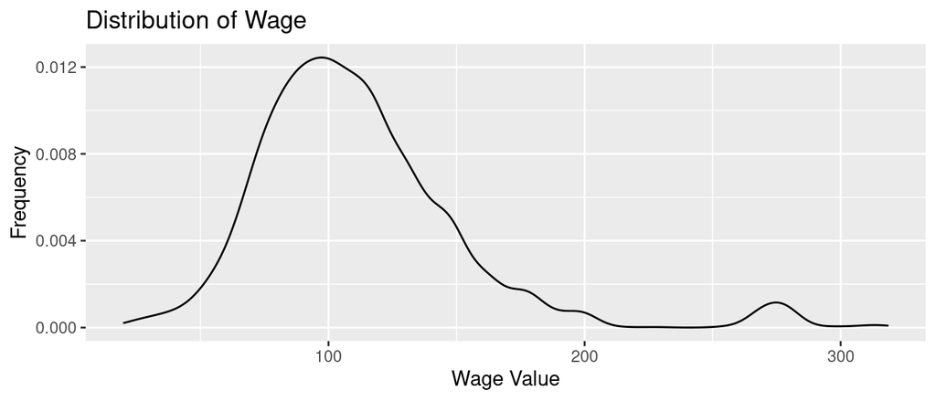

```r
qplot(wage, data=Wage, geom="density", alpha=I(.5), main="Distribution of Wage", xlab= "Wage Value", ylab="Frequency")
```

### Box plot of wage and education

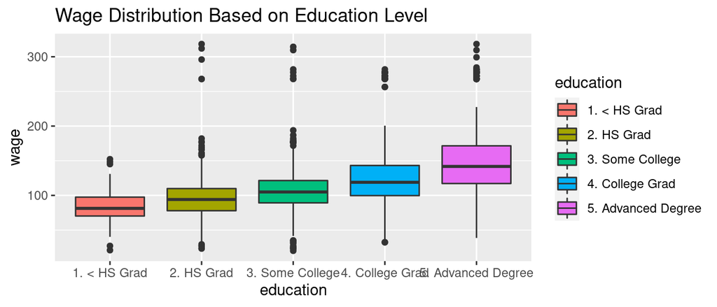

```r
qplot(x=education, y=wage, data= Wage, geom=c("boxplot"), fill=education) +
ggtitle("Wage Distribution Based on Education Level")
```

### Box plot of wage and race

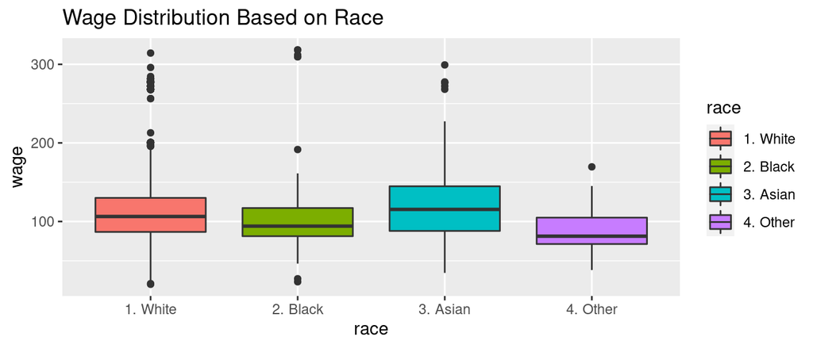

```r
qplot(x=race, y=wage, data= Wage, geom=c("boxplot"), fill=race ) +
ggtitle("Wage Distribution Based on Race")
```

### Box plot of wage and health

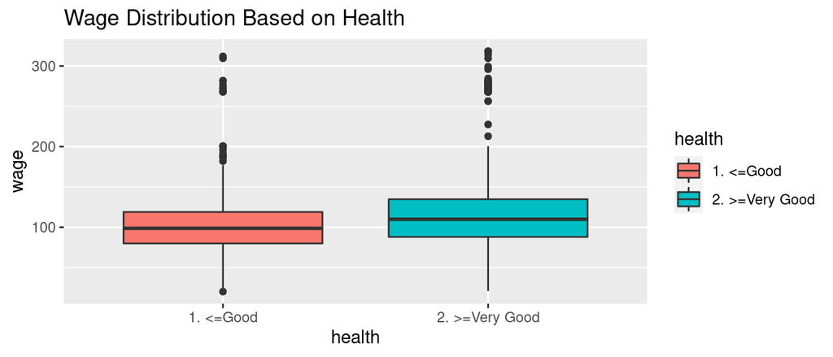

```r
qplot(x=health, y=wage, data= Wage, geom=c("boxplot"), fill=health) +
ggtitle("Wage Distribution Based on Health")
```

### Bar graph of number of observations by race

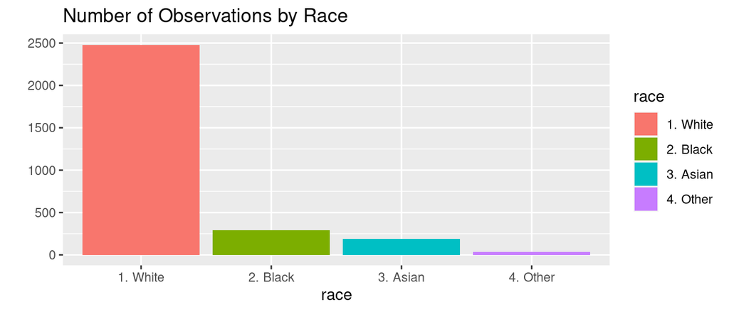

```r
qplot(x=race,  data=Wage, geom="bar", fill=race) +
ggtitle("Number of Observations by Race")
```

# Results

### Bivariate Regression model of wage and education

```r
Wage_Ed_Model <- lm(wage~education, data = Wage)
summary(Wage_Ed_Model)
```

```
##
## Call:
## lm(formula = wage ~ education, data = Wage)
##
## Residuals:
##     Min      1Q  Median      3Q     Max
## -112.31  -19.94   -3.09   15.33  222.56
##
## Coefficients:
##                             Estimate Std. Error t value Pr(>|t|)
## (Intercept)                   84.104      2.231  37.695  < 2e-16 ***
## education2. HS Grad           11.679      2.520   4.634 3.74e-06 ***
## education3. Some College      23.651      2.652   8.920  < 2e-16 ***
## education4. College Grad      40.323      2.632  15.322  < 2e-16 ***
## education5. Advanced Degree   66.813      2.848  23.462  < 2e-16 ***
## ---
## Signif. codes:  0 '***' 0.001 '**' 0.01 '*' 0.05 '.' 0.1 ' ' 1
##
## Residual standard error: 36.53 on 2995 degrees of freedom
## Multiple R-squared:  0.2348, Adjusted R-squared:  0.2338
## F-statistic: 229.8 on 4 and 2995 DF,  p-value: < 2.2e-16
```

#### This regression uses a linear model to estimate the relationship between education level and wage. The coefficients for education level are being contrasted with any education less than a high school education.

#### The coefficient for high school diploma=11.679, some college=23.651, college diploma=40.323, advanced degree=66.813. These results are significant due to the associated p-values. The results of the model show that wage earnings increase significantly with each educational attainment. On average, people with a high school degree make $11,679 more than those without a high school degree. A college degree increases that difference to $40,323 and an advanced degree to $66,813. The most significant wage earning difference is between a college and advanced degree, with a difference of over $26,000.

#### Based on the results of this model, we can reject our null hypothesis and conclude that, in this population, education does affect wage earnings.

## Multiple regression model of wage, education and race

```r
Wage_Ed_Race_Model <- lm(wage~education + race, data = Wage)
summary(Wage_Ed_Race_Model)
```

```
##
## Call:
## lm(formula = wage ~ education + race, data = Wage)
##
## Residuals:
##      Min       1Q   Median       3Q      Max
## -113.309  -20.424   -3.502   14.975  227.966
##
## Coefficients:
##                             Estimate Std. Error t value Pr(>|t|)
## (Intercept)                   85.535      2.265  37.762  < 2e-16 ***
## education2. HS Grad           11.219      2.523   4.447 9.04e-06 ***
## education3. Some College      23.375      2.655   8.805  < 2e-16 ***
## education4. College Grad      39.705      2.642  15.026  < 2e-16 ***
## education5. Advanced Degree   66.380      2.864  23.180  < 2e-16 ***
## race2. Black                  -6.378      2.264  -2.817  0.00488 **
## race3. Asian                  -4.046      2.782  -1.455  0.14587
## race4. Other                 -11.365      6.064  -1.874  0.06101 .
## ---
## Signif. codes:  0 '***' 0.001 '**' 0.01 '*' 0.05 '.' 0.1 ' ' 1
##
## Residual standard error: 36.47 on 2992 degrees of freedom
## Multiple R-squared:  0.238,  Adjusted R-squared:  0.2362
## F-statistic: 133.5 on 7 and 2992 DF,  p-value: < 2.2e-16
```

## Multiple regression model of wage, education and health

```r
Wage_Ed_Health_Model <- lm(wage~education + health, data = Wage)
summary(Wage_Ed_Health_Model)
```

```
##
## Call:
## lm(formula = wage ~ education + health, data = Wage)
##
## Residuals:
##      Min       1Q   Median       3Q      Max
## -113.404  -20.914   -3.622   15.940  220.416
##
## Coefficients:
##                             Estimate Std. Error t value Pr(>|t|)
## (Intercept)                   80.136      2.396  33.439  < 2e-16 ***
## education2. HS Grad           11.383      2.513   4.529 6.16e-06 ***
## education3. Some College      22.885      2.649   8.639  < 2e-16 ***
## education4. College Grad      39.052      2.639  14.798  < 2e-16 ***
## education5. Advanced Degree   65.227      2.861  22.797  < 2e-16 ***
## health2. >=Very Good           6.648      1.494   4.449 8.96e-06 ***
## ---
## Signif. codes:  0 '***' 0.001 '**' 0.01 '*' 0.05 '.' 0.1 ' ' 1
##
## Residual standard error: 36.41 on 2994 degrees of freedom
## Multiple R-squared:  0.2399, Adjusted R-squared:  0.2386
## F-statistic:   189 on 5 and 2994 DF,  p-value: < 2.2e-16
```

#### We also looked at the variable of health in relation to education and wage. The base comparison group is those with health that is less than or equal to “good.” The coefficient for very good health is 6.648. Compared to this group, those with very good health make $6,648 more on average than those with good health. This further shows that a number of variables impact wage beyond education level.

# Conclusion

#### Overall, we found that education had a significant effect on wage level. There was a correlation between educational attainment and wage which was positive as education level increased. However, we also determined that education was not the only variable which affects wage level. Factors such as race and health also have significant impacts on how much a person earns, and there are likely a number of other areas which can affect wage.